# PM 591 – Machine Learning for the Health Sciences.

Haoran Zhang

Due 4/18/2022

### Exercise 1 (Analysis/conceptual)

You will assess how well a tree model can capture non-linearities by fitting a regression tree to simulated non-linear data.

1. Simulate the data

```r
library(mlr)
library(randomForest)
```

```r
library(rpart)
library(rpart.plot)

set.seed(1984)
n = 1000
x = runif(n, -5, 5) # n observations uniformly distributed in the interval -5 to 5
error = rnorm(n, sd=0.5)
y = sin(x) + error # nonlinear relationship between outcome y and feature x
nonlin = data.frame(y=y, x=x)
```

```r
train = sample(1:nrow(nonlin), floor(nrow(nonlin)*0.5)); test = setdiff(1:nrow(nonlin), train)
```

3. Fit a regression tree using the trainig set

```r
library(rpart)
treefit = rpart(y~x, method='anova', control=list(cp=0), data=nonlin[train,]) # Method='anova' indicate sregression tree. cp=0 ensures that binary recursive partitioning will not stop early due to lack of improvement in RSS by an amount  of at least cp
```

4. Plot the fitted regression tree

[figure not shown]

```r
plot(treefit) # plots the tree
text(treefit) # annotates the tree. May fail if tree is too large
```

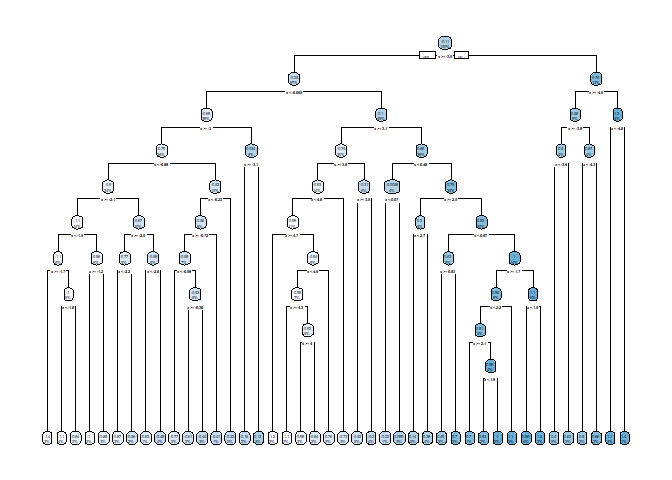

```r
library(rpart.plot)
rpart.plot(treefit) #the rpart.plot function generates better looking trees!
```

Note: the height of the branches are proportional to the improvement in RSS

22. Plot the cv relative error to determine the optimal complexity parameter

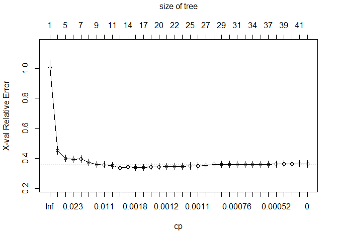

```r
plotcp(treefit)
```

6. Print the table complexity parameter values and their associated cv-errors

```r
printcp(treefit)
```

```
##
## Regression tree:
## rpart(formula = y ~ x, data = nonlin[train, ], method = "anova",
##     control = list(cp = 0))
##
## Variables actually used in tree construction:
## [1] x
##
## Root node error: 419.01/500 = 0.83803
##
## n= 500
##
##            CP nsplit rel error  xerror     xstd
## 1  0.19469747      0   1.00000 1.00402 0.050219
## 2  0.03406113      3   0.41591 0.45381 0.026383
```

[output cut: 32 more lines]

7. Select the optimal complexity parameter and prune the tree

```r
optimalcp = treefit$cptable[which.min(treefit$cptable[,"xerror"]),"CP"] # for you to fill in
treepruned = prune(treefit, cp=optimalcp)
```

8. Plot the pruned tree

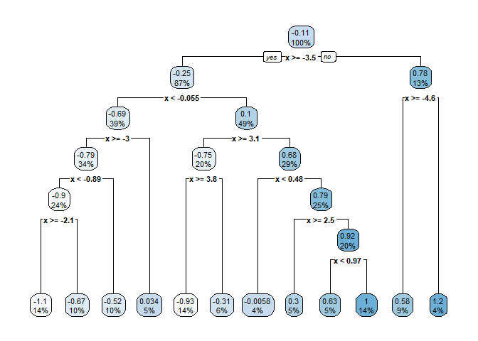

```r
rpart.plot(treepruned)
```

9. Summarize the pruned tree object and relate the summary to the plotted tree above

```r
summary(treepruned)
```

```
## Call:
## rpart(formula = y ~ x, data = nonlin[train, ], method = "anova",
##     control = list(cp = 0))
##   n= 500
##
##             CP nsplit rel error    xerror       xstd
## 1  0.194697471      0 1.0000000 1.0040153 0.05021945
## 2  0.034061135      3 0.4159076 0.4538104 0.02638272
## 3  0.027393414      4 0.3818465 0.4005153 0.02381225
## 4  0.018916616      5 0.3544530 0.3935674 0.02372447
## 5  0.018741339      6 0.3355364 0.3960865 0.02397866
## 6  0.012132319      7 0.3167951 0.3733062 0.02312415
## 7  0.011774257      8 0.3046628 0.3603378 0.02145075
## 8  0.010680660      9 0.2928885 0.3578205 0.02147093
## 9  0.007302594     10 0.2822078 0.3534446 0.02167188
## 10 0.002272669     11 0.2749053 0.3370788 0.02130490
##
## Variable importance
##   x
## 100
##
## Node number 1: 500 observations,    complexity param=0.1946975
##   mean=-0.1147421, MSE=0.8380283
##   left son=2 (436 obs) right son=3 (64 obs)
##   Primary splits:
##       x < -3.484362   to the right, improve=0.1407386, (0 missing)
##
## Node number 2: 436 observations,    complexity param=0.1946975
##   mean=-0.2463199, MSE=0.7852125
##   left son=4 (193 obs) right son=5 (243 obs)
##   Primary splits:
##       x < -0.05508361 to the left,  improve=0.1965717, (0 missing)
##
## Node number 3: 64 observations,    complexity param=0.01213232
##   mean=0.781632, MSE=0.2764066
##   left son=6 (43 obs) right son=7 (21 obs)
##   Primary splits:
##       x < -4.612867   to the right, improve=0.2873718, (0 missing)
##
## Node number 4: 193 observations,    complexity param=0.03406113
```

[output cut: 67 more lines]

```
##
## Node number 46: 26 observations
##   mean=0.3027775, MSE=0.233719
##
## Node number 47: 98 observations,    complexity param=0.007302594
##   mean=0.9238571, MSE=0.2530437
##   left son=94 (26 obs) right son=95 (72 obs)
##   Primary splits:
##       x < 0.9713606   to the left,  improve=0.1233912, (0 missing)
##
## Node number 94: 26 observations
##   mean=0.6298082, MSE=0.2488088
##
## Node number 95: 72 observations
##   mean=1.030041, MSE=0.2120744
```

24. Based on the plot and/or summary of the pruned tree create a vector of the (ordered) split points for variable x, and a vector of fitted values for the intervals determined by the split points of x.

```r
# for you to fill in
x_splits = c(-4.6,-3.5,-2.96,-2.1,-0.89,-0.055,0.48,0.97,2.5,3.1,3.8)

y_splits = c(1.2, 0.78,0.034,-0.67,-1.1,-0.52,-0.0058,0.58,1,0.63,-0.31,-0.93)
```

11. Plot the step function corresponding to the fitted (pruned) tree

```r
plot(y~x, data=nonlin[train,])
stpfn = stepfun(x_splits, y_splits) #stepfun creates the step function
plot(stpfn, add=TRUE, lwd=2, col='red4') #add=TRUE plots over the existing plot
```

[output not shown]

12. Fit a linear model to the training data and plot the regression line. Contrats the quality of the fit of the tree model vs. linear regression by inspection of the plot

```r
lmfit = lm(y ~ x, data=nonlin[train,])
summary(lmfit)
```

```
##
## Call:
## lm(formula = y ~ x, data = nonlin[train, ])
##
## Residuals:
##      Min       1Q   Median       3Q      Max
## -2.11037 -0.69868 -0.06587  0.68081  2.42672
##
## Coefficients:
##             Estimate Std. Error t value Pr(>|t|)
## (Intercept) -0.11249    0.04072  -2.762  0.00595 **
## x           -0.03891    0.01414  -2.752  0.00614 **
## ---
## Signif. codes:  0 '***' 0.001 '**' 0.01 '*' 0.05 '.' 0.1 ' ' 1
##
## Residual standard error: 0.9104 on 498 degrees of freedom
## Multiple R-squared:  0.01498,    Adjusted R-squared:  0.013
## F-statistic: 7.573 on 1 and 498 DF,  p-value: 0.00614
```

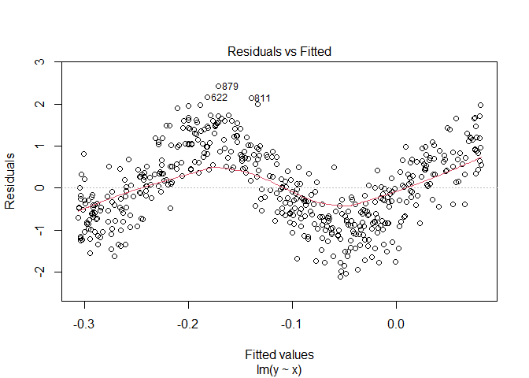

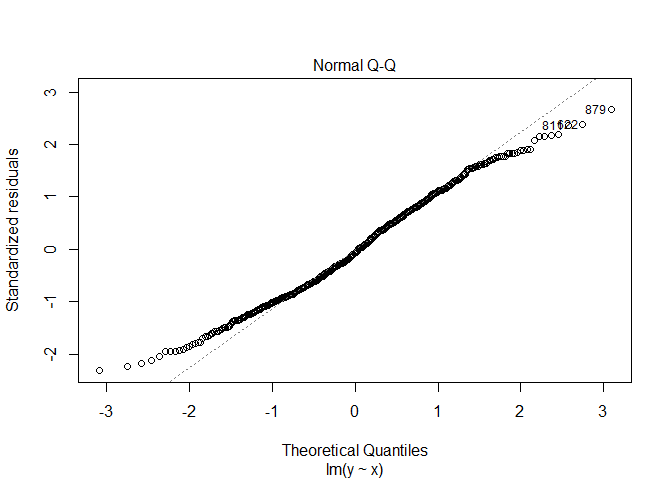

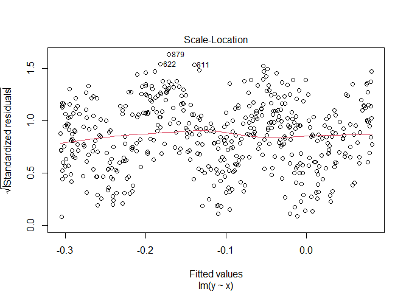

```r
plot(lmfit)
```

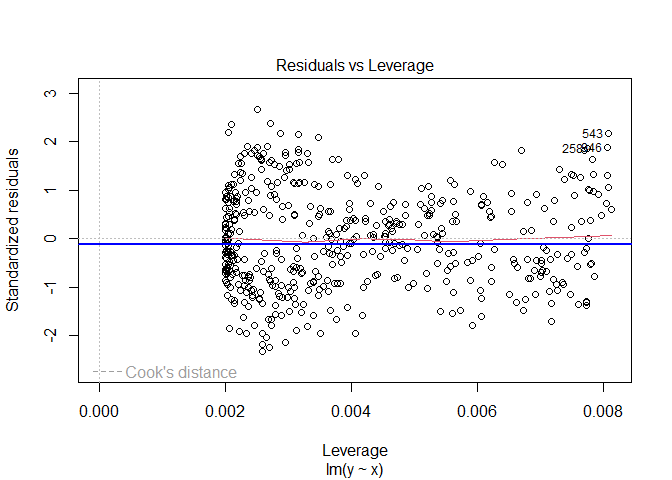

```r
abline(lmfit, col='blue', lwd=2)
```

### Exercise 2 (Analysis)

You will recreate the analysis of the heart data in the textbook and lecture.

```r
heart <- read.csv("Heart.csv")
require(mlr)
require(randomForest)
require(rpart)
require(rpart.plot)

set.seed(301)
heart <- heart[complete.cases(heart), ]

heart$ChestPain <- as.factor(heart$ChestPain)
heart$Thal <- as.factor(heart$Thal)
heart$AHD <- as.factor(heart$AHD)
heart$AHD <- as.numeric(heart$AHD)-1
```

1. Split the data into training and testing

```r
nh <- nrow(heart)
train_heart = sample(1:nrow(heart), floor(nrow(heart)*0.7)); test_heart = setdiff(1:nrow(heart), train)
```

2. Fit a classification tree using `rpart`

```r
set.seed(301)
treefit_heart = rpart(AHD~., method='class', control=list(cp=0), data=heart[train_heart,])
```

3. Plot the unpruned tree

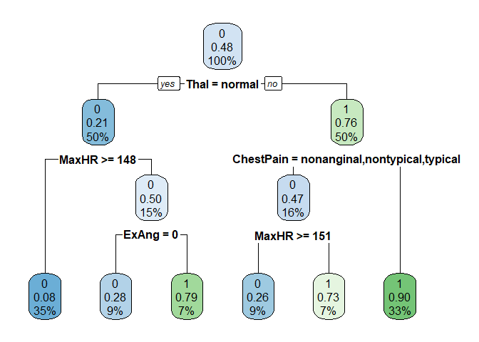

```r
rpart.plot(treefit_heart)
```

4. Plot the cv error

```r
min(treefit_heart$cptable[,"xerror"])*nrow(heart[train_heart,])
```

```
## [1] 93.15
```

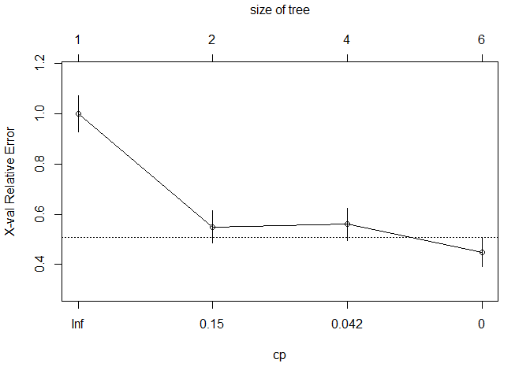

```r
plotcp(treefit_heart)
```

22. Prune the tree using the optimal complexity parameter

```r
optimalcp_heart = treefit_heart$cptable[which.min(treefit_heart$cptable[,"xerror"]),"CP"]
treepruned_heart = prune(treefit_heart, cp=optimalcp_heart)
treepruned_heart$cptable
```

```
##      CP nsplit rel error xerror       xstd
## 1 0.530      0      1.00   1.00 0.07189633
## 2 0.045      1      0.47   0.55 0.06355035
## 3 0.040      3      0.38   0.56 0.06391419
## 4 0.000      5      0.30   0.45 0.05934424
```

6. Plot the pruned tree

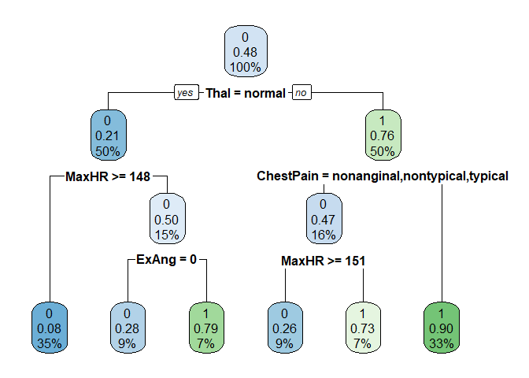

```r
rpart.plot(treepruned_heart)
```

7. Compute the test misclassification error

```r
treepruned_heart_predict = predict(treepruned_heart, newdata =heart[test_heart,], type='prob')
```

```r
library(pROC)
roc_test_heart = roc(heart$AHD[test_heart], treepruned_heart_predict[,1])
print(auc(roc_test_heart))
```

```
## Area under the curve: 0.8654
```

```r
print(ci.auc(roc_test_heart))
```

```
## 95% CI: 0.8026-0.9282 (DeLong)
```

```r
cm <- table(heart$AHD[test_heart], as.numeric(treepruned_heart_predict[,1]>0.5))
    mmce <- 1 - (sum(diag(cm))/sum(cm))
    print(mmce)
```

```
## [1] 0.8333333
```

7. Fit the tree with the optimal complexity parameter to the full data (training + testing)

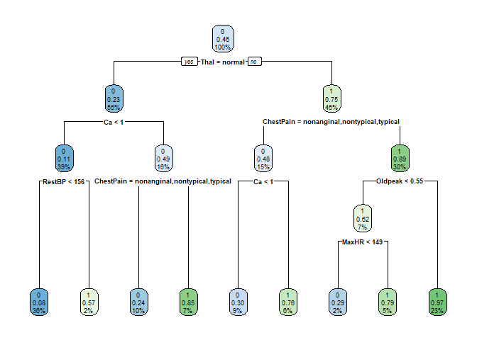

```r
set.seed(301)
heart_full = rpart(AHD~., method='class', control=list(cp=0), data=heart)
rpart.plot(heart_full)
```

```r
optimalcp_full = heart_full$cptable[which.min(heart_full$cptable[,"xerror"]),"CP"]
optimalcp_full
```

```
## [1] 0.01094891
```

```r
treepruned_full = prune(heart_full, cp=optimalcp_full)
treepruned_full$cptable
```

```
##           CP nsplit rel error    xerror       xstd
## 1 0.48905109      0 1.0000000 1.0000000 0.06270779
## 2 0.05109489      1 0.5109489 0.5620438 0.05512618
## 3 0.04014599      3 0.4087591 0.5109489 0.05339040
## 4 0.01094891      5 0.3284672 0.4014599 0.04886414
```

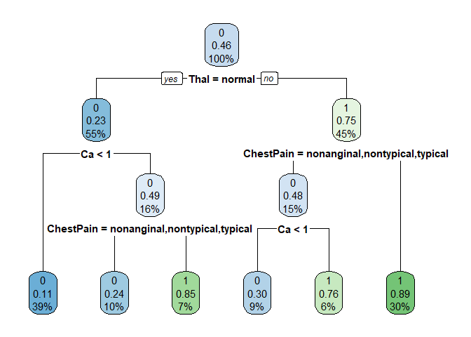

```r
rpart.plot(treepruned_full)
```

```r
heart_full$cptable
```

```
##           CP nsplit rel error    xerror       xstd
## 1 0.48905109      0 1.0000000 1.0000000 0.06270779
## 2 0.05109489      1 0.5109489 0.5620438 0.05512618
## 3 0.04014599      3 0.4087591 0.5109489 0.05339040
## 4 0.01094891      5 0.3284672 0.4014599 0.04886414
## 5 0.00729927      7 0.3065693 0.4014599 0.04886414
## 6 0.00000000      8 0.2992701 0.4160584 0.04953866
```

```r
# cross validation error
min(heart_full$cptable[,"xerror"])*nrow(heart)
```

```
## [1] 119.2336
```

### Exercise 3 – Analysis

Compare the performance of classification trees, bagging, random forests, and boosting for predicting heart disease based on the `heart` data.

1. Split the data into training and testing. Train each of the models on the training data and extract the cross-validation (or out-of-bag error for bagging and Random forest).

```r
train = sample(1:nrow(heart), floor(nrow(heart)*0.7)); test = setdiff(1:nrow(heart), train)
```

```r
library(rattle)
```

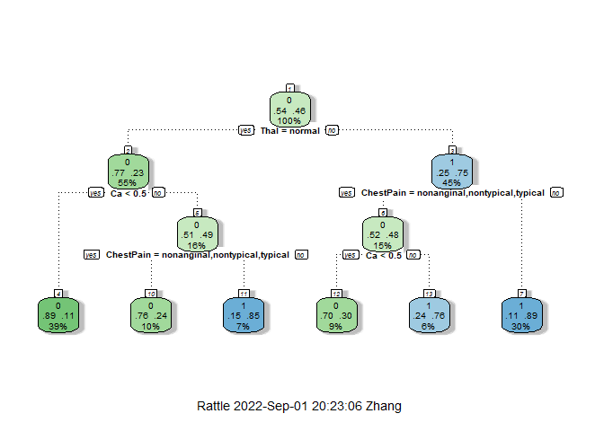

```r
heart_cl = rpart(AHD ~ ., data=heart, method='class',
 control=list(minsplit = 15, minbucket = 5, cp = 0))

heart_cl_pruned = prune(heart_cl, cp=0.032)
fancyRpartPlot(heart_cl_pruned, cex=0.6, yesno=2)
```

```r
set.seed(301)
heart_bg = randomForest(as.factor(AHD) ~ . , data = heart[train,],
                        strata = heart$AHD[train],
                        sampsize = as.vector(table(heart$AHD[train])))
#oob error rate
sum(heart_bg$err.rate[,1])
```

```
## [1] 101.9358
```

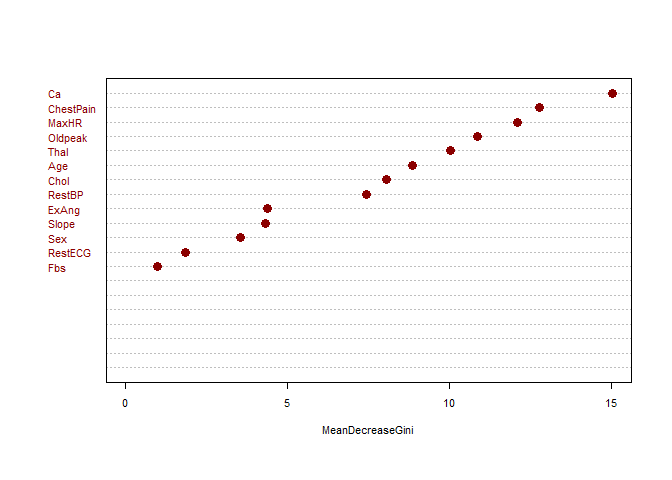

```r
varImpPlot(heart_bg, cex = 0.7, pt.cex = 1.2, n.var = 20, main = "", pch = 16,
 col = "red4")
```

```r
#varimp = round(summary(heart_tree_pruned)$variable.importance, 2)
```

```r
heart_rf = randomForest(as.factor(AHD) ~ . , data = heart[train,],
                        mtry=dim(heart[train,])[2]-1,
                        strata = heart$AHD[train],
                        sampsize = as.vector(table(heart$AHD[train])))
#oob error rate
sum(heart_rf$err.rate[,1])
```

```
## [1] 111.6684
```

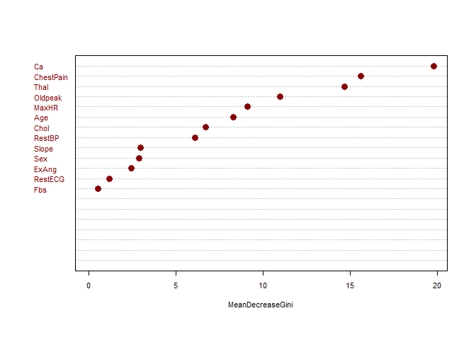

```r
varImpPlot(heart_rf, cex = 0.7, pt.cex = 1.2, n.var = 20, main = "", pch = 16,
 col = "red4")
```

```r
#important.par<-importance(heart_rf)[order(importance(heart_rf)[,1], decreasing = TRUE),]
```

4. For boosting use `gbm` with `cv.folds=5` to perform 5-fold cross-validation, and set `class.stratify.cv` to `AHD` (heart disease outcome) so that cross-validation is performed stratifying by `AHD`. Plot the cross-validation error as a function of the boosting iteration/trees (the `$cv.error` component of the object returned by `gbm`) and determine whether additional boosting iterations are warranted. If so, run additional iterations with `gbm.more` (use the R help to check its syntax). Choose the optimal number of iterations. Use the `summary.gbm` function to generate the variable importance plot and extract variable importance/influence (`summary.gbm` does both). Generate 1D and 2D marginal plots with `gbm.plot` to assess the effect of the top three variables and their 2-way interactions.

```r
library(gbm, warn.conflicts = FALSE)
```

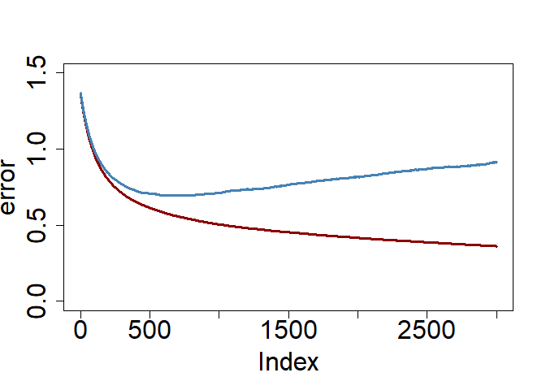

```r
n <- nrow(heart)
train = sample(1:nrow(heart), floor(nrow(heart)*0.7)); test = setdiff(1:nrow(heart), train)

set.seed(301)
heart_boost = gbm(AHD ~ . , data=heart[train,],
                    distribution='bernoulli', n.trees=3000,
                    interaction.depth = 1,
                    shrinkage = 0.01,
                    cv.folds=5, class.stratify.cv=TRUE)

plot(heart_boost$train.error, cex.lab=2, cex.axis=2, col='red4', type='l', lwd=3,
         ylim=c(0,1.5), ylab="error")
lines(heart_boost$cv.error, col='steelblue', lwd=3)
```

```r
print("===random forest===")
```

```
## [1] "===random forest==="
```

```r
heart_rf_predict = predict(heart_rf, newdata = heart[test, ],
                              type='response')

roc_test = roc(heart$AHD[test], as.numeric(heart_rf_predict)-1)
auc(roc_test); ci.auc(roc_test)
```

```
## Area under the curve: 0.9332
```

```
## 95% CI: 0.8809-0.9855 (DeLong)
```

```r
cm <- table(heart$AHD[test], as.numeric(heart_rf_predict)-1)
mmce <- 1 - (sum(diag(cm))/sum(cm))
mmce
```

```
## [1] 0.06666667
```

```r
print("===bagging===")
```

```
## [1] "===bagging==="
```

```r
heart_bg_predict = predict(heart_bg, newdata = heart[test, ],
                              type='response')

roc_test = roc(heart$AHD[test], as.numeric(heart_bg_predict)-1)
auc(roc_test); ci.auc(roc_test)
```

```
## Area under the curve: 0.9332
```

```
## 95% CI: 0.8809-0.9855 (DeLong)
```

```r
cm <- table(heart$AHD[test], as.numeric(heart_bg_predict)-1)
mmce <- 1 - (sum(diag(cm))/sum(cm))
mmce
```

```
## [1] 0.06666667
```

```r
print("===boost===")
```

```
## [1] "===boost==="
```

```r
heart_boost_predict = predict(heart_boost, newdata = heart[test, ],
                              type='response', n.trees=which.min(heart_boost$cv.error))


roc_test = roc(heart$AHD[test], as.numeric(heart_boost_predict>0.5))
auc(roc_test); ci.auc(roc_test)
```

```
## Area under the curve: 0.8209
```

```
## 95% CI: 0.7407-0.9011 (DeLong)
```

```r
cm <- table(heart$AHD[test], as.numeric(heart_boost_predict>0.5))
mmce <- 1 - (sum(diag(cm))/sum(cm))
mmce
```

```
## [1] 0.1777778
```

2. (Extra Credit) Perform the comparison between methods in i) using mlr3 benchmark and add to the mix of methods the boosting implemented in xgboost

### Exercise 3 – Analysis/conceptual

Yo will evaluate the effect of critical boosting parameters (number of boosting iterations, shrinkage/learning rate, and tree depth/interaction) on the Metabric data. In `gbm` the number of iterations is controlled by `n.trees` (default is 100), the shrinkage/learning rate is controlled by `shrinkage` (default is 0.001), and interaction depth by `interaction.depth` (default is 1).

1. Split the metabric data into training and testing.

```r
load("metabric.Rdata")
set.seed(2022)
train = sample(1:nrow(metabric), floor(nrow(metabric)*0.7));
test = setdiff(1:nrow(metabric), train)
table(metabric$y[train])
```

```
##
##   0   1
## 455 107
```

```r
metabric$y <- as.numeric(metabric$y)-1
```

2. Set the seed and train a boosting classification with `gbm` using 10-fold cross-validation (`cv.folds=10`) on the training data with `n.trees = 5,000`, `shrinkage = 0.001`, and `interaction.depth =1`. Plot the cross-validation errors as a function of the boosting iteration.

```r
library(gbm, warn.conflicts = FALSE)
set.seed(2022)
   metabric_boost= gbm(y ~ . , data=metabric[train,],
                    distribution='bernoulli', n.trees=5000,
                    interaction.depth = 1,
                    shrinkage = 0.001,
                    cv.folds=10, class.stratify.cv=TRUE)
```

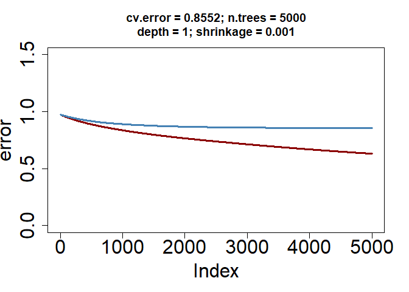

```r
plot(metabric_boost$train.error, cex.lab=2, cex.axis=2, col='red4', type='l', lwd=3,  xlim=c(0,5000),
         ylim=c(0,1.5), ylab="error", main= paste0("cv.error = ",round(min(metabric_boost$cv.error),4),
                                                   "; n.trees = ", 5000,
                                                   "\ndepth = ", 1, "; shrinkage = ", 0.001))
lines(metabric_boost$cv.error, col='steelblue', lwd=3)
```

```r
metabric_boost_predict = predict(metabric_boost, newdata = metabric[test, ], type='response')
```

```
## Using 4675 trees...
```

```r
require(pROC)
roc_test = roc(metabric$y[test], metabric_boost_predict)
    print(auc(roc_test))
```

```
## Area under the curve: 0.6745
```

```r
    print(ci.auc(roc_test))
```

```
## 95% CI: 0.5711-0.778 (DeLong)
```

```r
    cm <- table(metabric$y[test], as.numeric(metabric_boost_predict>0.5))
    mmce <- 1 - (sum(diag(cm))/sum(cm))
    print(mmce)
```

```
## [1] 0.153527
```

```r
library(pROC)
##a.a
as.data.frame(head(summary(metabric_boost, plotit = FALSE), 3))
```

```
##                       var  rel.inf
## ILMN_2166524 ILMN_2166524 7.637979
## ILMN_1770085 ILMN_1770085 6.313024
## ILMN_1780188 ILMN_1780188 4.042201
```

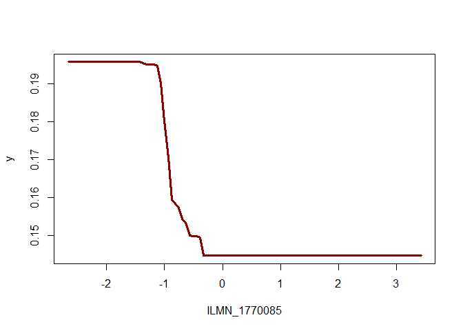

```r
pa1 = plot(metabric_boost, i.var=c('ILMN_1770085'), type='response', return.grid=TRUE)
plot(pa1, type ='l', lwd=3, col='red4', cex.axis=1, cex.lab=1)
```

iii. Repeat ii. using the same seed and `n.trees=5,000` with the following 3 additional combination of parameters: a) `shrinkage = 0.001`, `interaction.depth = 2`; b) `shrinkage = 0.01`, `interaction.depth = 1`; c) `shrinkage = 0.01`, `interaction.depth = 2`.

```r
library(gbm, warn.conflicts = FALSE)
set.seed(2022)
   metabric_boost_a = gbm(y ~ . , data=metabric[train,],
                    distribution='bernoulli', n.trees=5000,
                    interaction.depth = 2,
                    shrinkage = 0.001,
                    cv.folds=10, class.stratify.cv=TRUE)
   metabric_boost_b = gbm(y ~ . , data=metabric[train,],
                    distribution='bernoulli', n.trees=5000,
                    interaction.depth = 1,
                    shrinkage = 0.01,
                    cv.folds=10, class.stratify.cv=TRUE)
   metabric_boost_c = gbm(y ~ . , data=metabric[train,],
                    distribution='bernoulli', n.trees=5000,
                    interaction.depth = 2,
                    shrinkage = 0.01,
                    cv.folds=10, class.stratify.cv=TRUE)
```

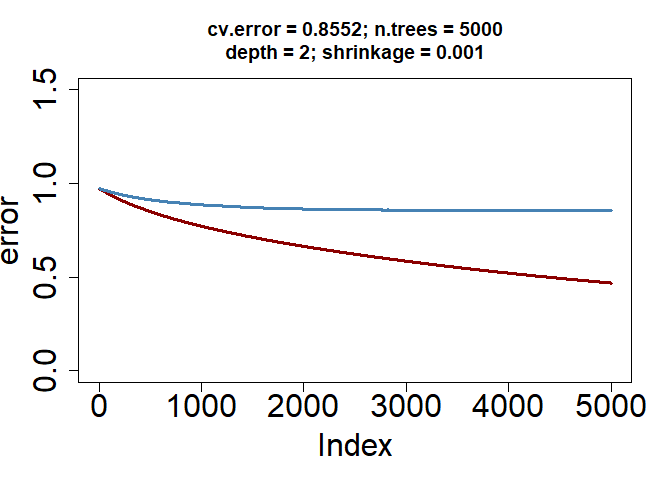

```r
plot(metabric_boost_a$train.error, cex.lab=2, cex.axis=2, col='red4', type='l', lwd=3,  xlim=c(0,5000),
         ylim=c(0,1.5), ylab="error", main= paste0("cv.error = ",round(min(metabric_boost_a$cv.error),4),
                                                   "; n.trees = ", 5000,
                                                   "\ndepth = ", 2, "; shrinkage = ", 0.001))
lines(metabric_boost_a$cv.error, col='steelblue', lwd=3)
```

```r
metabric_boost_a_predict = predict(metabric_boost_a, newdata = metabric[test, ], type='response')
```

```
## Using 4069 trees...
```

```r
require(pROC)
roc_test_a = roc(metabric$y[test], metabric_boost_a_predict)
    print(auc(roc_test_a))
```

```
## Area under the curve: 0.6796
```

```r
    print(ci.auc(roc_test_a))
```

```
## 95% CI: 0.5774-0.7818 (DeLong)
```

```r
    cm <- table(metabric$y[test], as.numeric(metabric_boost_a_predict>0.5))
    mmce <- 1 - (sum(diag(cm))/sum(cm))
    print(mmce)
```

```
## [1] 0.1493776
```

```r
library(pROC)
##a.a
as.data.frame(head(summary(metabric_boost_a, plotit = FALSE), 3))
```

```
##                       var  rel.inf
## ILMN_2166524 ILMN_2166524 4.740165
## ILMN_1770085 ILMN_1770085 3.635768
## ILMN_1780188 ILMN_1780188 2.607487
```

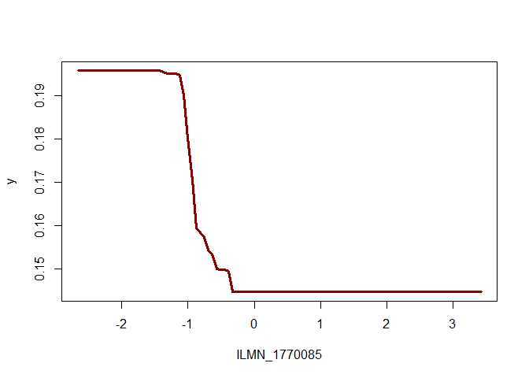

```r
pa1_a = plot(metabric_boost, i.var=c('ILMN_1770085'), type='response', return.grid=TRUE)
plot(pa1, type ='l', lwd=3, col='red4', cex.axis=1, cex.lab=1)
```

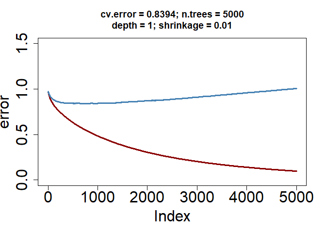

```r
plot(metabric_boost_b$train.error, cex.lab=2, cex.axis=2, col='red4', type='l', lwd=3,  xlim=c(0,5000),
         ylim=c(0,1.5), ylab="error", main= paste0("cv.error = ",round(min(metabric_boost_b$cv.error),4),
                                                   "; n.trees = ", 5000,
                                                   "\ndepth = ", 1, "; shrinkage = ", 0.01))
lines(metabric_boost_b$cv.error, col='steelblue', lwd=3)
```

```r
metabric_boost_b_predict = predict(metabric_boost_b, newdata = metabric[test, ], type='response')
```

```
## Using 711 trees...
```

```r
require(pROC)
roc_test_b = roc(metabric$y[test], metabric_boost_b_predict)
    print(auc(roc_test_b))
```

```
## Area under the curve: 0.6772
```

```r
    print(ci.auc(roc_test_b))
```

```
## 95% CI: 0.5733-0.7811 (DeLong)
```

```r
    cm <- table(metabric$y[test], as.numeric(metabric_boost_b_predict>0.5))
    mmce <- 1 - (sum(diag(cm))/sum(cm))
    print(mmce)
```

```
## [1] 0.1618257
```

```r
library(pROC)
##a.a
as.data.frame(head(summary(metabric_boost_b, plotit = FALSE), 3))
```

```
##                       var  rel.inf
## ILMN_2166524 ILMN_2166524 3.086614
## ILMN_1780188 ILMN_1780188 2.232510
## ILMN_1838885 ILMN_1838885 2.196979
```

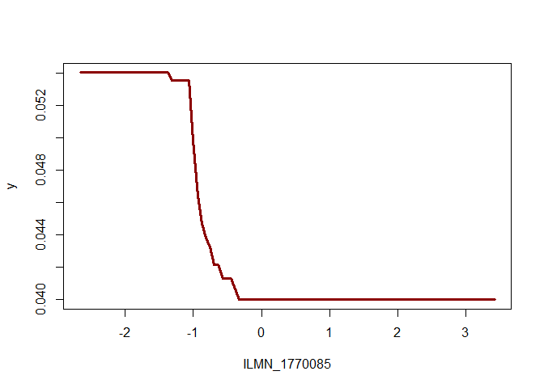

```r
pa1_b = plot(metabric_boost_b, i.var=c('ILMN_1770085'), type='response', return.grid=TRUE)
plot(pa1_b, type ='l', lwd=3, col='red4', cex.axis=1, cex.lab=1)
```

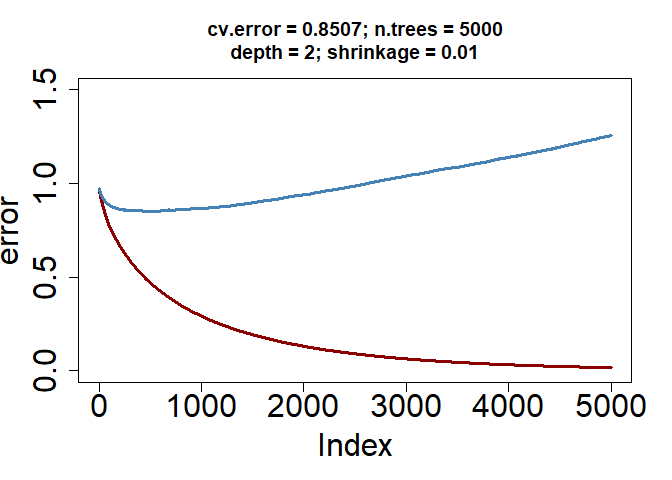

```r
plot(metabric_boost_c$train.error, cex.lab=2, cex.axis=2, col='red4', type='l', lwd=3,  xlim=c(0,5000),
         ylim=c(0,1.5), ylab="error", main= paste0("cv.error = ",round(min(metabric_boost_c$cv.error),4),
                                                   "; n.trees = ", 5000,
                                                   "\ndepth = ", 2, "; shrinkage = ", 0.01))
lines(metabric_boost_c$cv.error, col='steelblue', lwd=3)
```

```r
metabric_boost_c_predict = predict(metabric_boost_c, newdata = metabric[test, ], type='response')
```

```
## Using 467 trees...
```

```r
require(pROC)
roc_test_c = roc(metabric$y[test], metabric_boost_c_predict)
    print(auc(roc_test_c))
```

```
## Area under the curve: 0.6907
```

```r
    print(ci.auc(roc_test_c))
```

```
## 95% CI: 0.5894-0.7919 (DeLong)
```

```r
    cm <- table(metabric$y[test], as.numeric(metabric_boost_c_predict>0.5))
    mmce <- 1 - (sum(diag(cm))/sum(cm))
    print(mmce)
```

```
## [1] 0.1576763
```

```r
library(pROC)
##a.a
as.data.frame(head(summary(metabric_boost_c, plotit = FALSE), 3))
```

```
##                       var  rel.inf
## ILMN_2166524 ILMN_2166524 3.132056
## ILMN_1780188 ILMN_1780188 1.908543
## ILMN_1838885 ILMN_1838885 1.902303
```

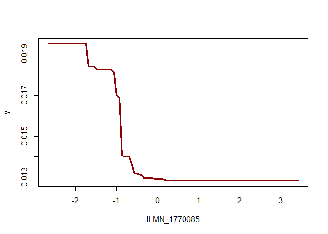

```r
pa1_c = plot(metabric_boost_c, i.var=c('ILMN_1770085'), type='response', return.grid=TRUE)
plot(pa1_c, type ='l', lwd=3, col='red4', cex.axis=1, cex.lab=1)
```

```r
metabric_boost_b_predict = predict(metabric_boost_b, newdata = metabric[test, ], type='response')
```

```
## Using 711 trees...
```

```r
require(pROC)
roc_test_b = roc(metabric$y[test], metabric_boost_b_predict)
    print(auc(roc_test_b))
```

```
## Area under the curve: 0.6772
```

```r
    print(ci.auc(roc_test_b))
```

```
## 95% CI: 0.5733-0.7811 (DeLong)
```

```r
    cm <- table(metabric$y[test], as.numeric(metabric_boost_b_predict>0.5))
    mmce <- 1 - (sum(diag(cm))/sum(cm))
    print(mmce)
```

```
## [1] 0.1618257
```

```r
library(pROC)
##a.a
as.data.frame(head(summary(metabric_boost_b, plotit = FALSE), 3))
```

```
##                       var  rel.inf
## ILMN_2166524 ILMN_2166524 3.086614
## ILMN_1780188 ILMN_1780188 2.232510
## ILMN_1838885 ILMN_1838885 2.196979
```

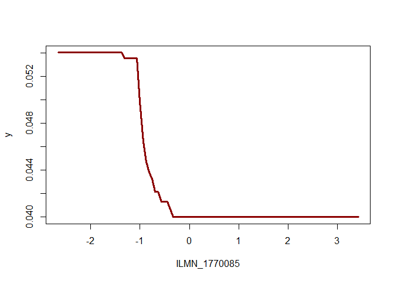

```r
pa1_b = plot(metabric_boost_b, i.var=c('ILMN_1770085'), type='response', return.grid=TRUE)
plot(pa1_b, type ='l', lwd=3, col='red4', cex.axis=1, cex.lab=1)
```